# Silver’s Price Performance Subsequent to Major One-Day Changes

Mark J. Badros, CFA

September 13, 2018

## Statement of the Problem

This short study analyzes the price performance of the iShares Silver Trust (“silver”; ticker:SLV) during the three-week period (15 trading days) following any day that the closing price of SLV changed (up or down) by at least 3% from the previous close.

## Historical Closing Price Data

Below is a chart of SLV’s daily closing price over this period:

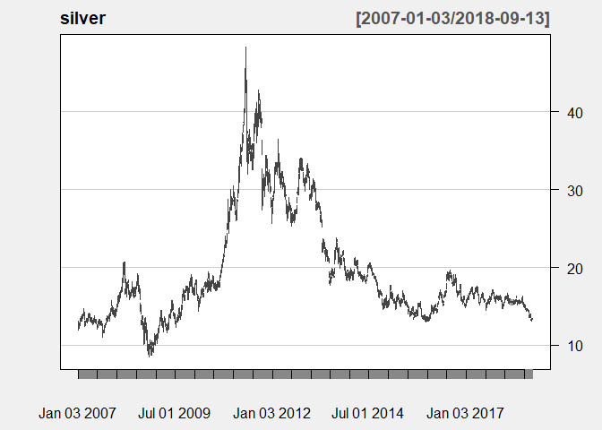

## Significant Daily Moves

A daily price change was significant if SLV’s closing price moved up or down at least 3% from the previous close (a “Major Daily Move”).

Below is a table summarizing the number of observations classified as a large decline (-3% or worse), a small decline (no change or less than 3% decline), a small gain (positive but not more than 3%) or a large gain (greater than 3%). (I have excluded the first observation because the change from the previous close was unavailable.)

| big_move | n | Percentage |
| --- | --- | --- |
| Large Decline | 168 | 5.7 |
| Small Decline | 1251 | 42.5 |
| Small Gain | 1377 | 46.8 |
| Large Gain | 149 | 5.1 |

This study is primarily concerned with the ~10.8% of days when SLV’s closing price changes by 3% or more from its previous close.

For each trading day, I calculated the simple return from the closing price to: - the closing price 15 trading days later, - the maximum closing price achieved during this period, and - the lowest closing price realized during this period.

Below is a plot of the simple return over 15 trading days (typically three weeks, ignoring holidays) following a Major Daily Move, as well as the simple return following a small daily price change. The boxplot overlay shows the 25th, 50th and 75th percentiles for returns observed. (Obviously, the returns for the most recent observations are as yet unknown because 15 days haven’t elapsed.)

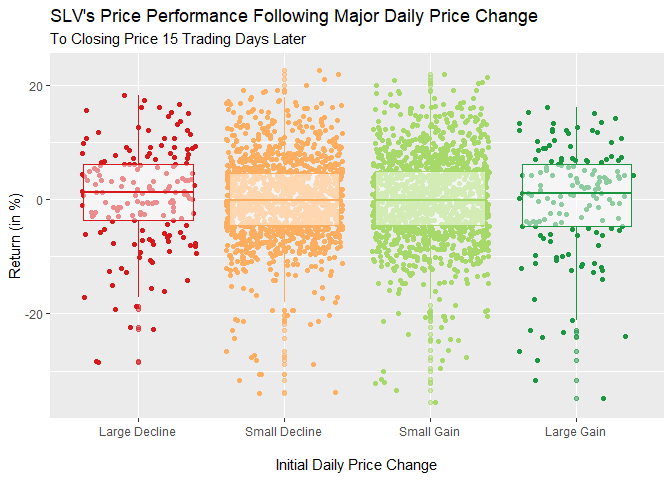

From this plot, you can see a slightly higher return over the next 15 trading days after a Major Daily Move, compared to days where the closing price has a smaller change.

## Price Performance to Highest Close over Next 15 Trading Days

Below is a plot of the return from a daily closing price to the maximum closing price attained during the subsequent 15 days. Again, the boxplot shows the 25th, 50th and 75th percentiles of this maximum (hypothetically) attainable return.

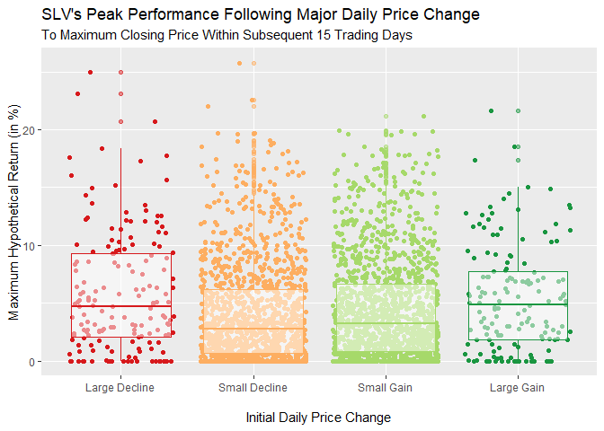

This plot depicts a larger effect where the percentage change to the highest close over the next 15 trading days is greater after a Major Daily Move (either up or down) than after a smaller daily price change.

## Worst Drawdown over Subsequent 15 Trading Days

Below is a plot of the return from a daily closing price to the lowest closing price observed during subsequent 15 days. Again, the boxplot shows the 25th, 50th and 75th percentiles of this worst realizable return.

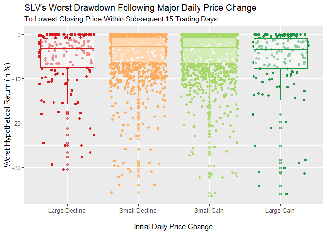

On average, the price change to the lowest closing price within the 15 trading days after a Major Daily Move is very slightly worse than after other trading days.

Code, underlying numerical results and calculations, and additional analyses available upon request. Please contact the author at mbadros@timberlakecapital.com.